# Risk Factor Analysis

## Outcome Variable

**Outcome Variable:** ever_swasted

## Predictor Variables

**Intervention Variable:** parity

**Adjustment Set:**

- arm
- W_mage
- meducyrs
- feducyrs
- hhwealth_quart
- W_mhtcm
- W_mwtkg
- W_mbmi
- vagbrth
- W_nrooms
- impsan
- delta_W_mage
- delta_meducyrs
- delta_feducyrs
- delta_hhwealth_quart
- delta_W_mhtcm
- delta_W_mwtkg
- delta_W_mbmi
- delta_vagbrth
- delta_W_nrooms
- delta_impsan

## Stratifying Variables

The analysis was stratified on these variable(s):

- agecat
- studyid
- country

## Data Summary

| agecat | studyid | country | parity | ever_swasted | n_cell | n |
| --- | --- | --- | --- | --- | --- | --- |
| 0-24 months | COHORTS | GUATEMALA | 1 | 0 | 191 | 1341 |
| 0-24 months | COHORTS | GUATEMALA | 1 | 1 | 17 | 1341 |
| 0-24 months | COHORTS | GUATEMALA | 2 | 0 | 172 | 1341 |
| 0-24 months | COHORTS | GUATEMALA | 2 | 1 | 15 | 1341 |
| 0-24 months | COHORTS | GUATEMALA | 3+ | 0 | 881 | 1341 |
| 0-24 months | COHORTS | GUATEMALA | 3+ | 1 | 65 | 1341 |
| 0-24 months | COHORTS | INDIA | 1 | 0 | 737 | 4624 |
| 0-24 months | COHORTS | INDIA | 1 | 1 | 73 | 4624 |
| 0-24 months | COHORTS | INDIA | 2 | 0 | 1082 | 4624 |
| 0-24 months | COHORTS | INDIA | 2 | 1 | 102 | 4624 |
| 0-24 months | COHORTS | INDIA | 3+ | 0 | 2336 | 4624 |
| 0-24 months | COHORTS | INDIA | 3+ | 1 | 294 | 4624 |
| 0-24 months | COHORTS | PHILIPPINES | 1 | 0 | 584 | 3045 |
| 0-24 months | COHORTS | PHILIPPINES | 1 | 1 | 93 | 3045 |
| 0-24 months | COHORTS | PHILIPPINES | 2 | 0 | 609 | 3045 |
| 0-24 months | COHORTS | PHILIPPINES | 2 | 1 | 73 | 3045 |
| 0-24 months | COHORTS | PHILIPPINES | 3+ | 0 | 1470 | 3045 |
| 0-24 months | COHORTS | PHILIPPINES | 3+ | 1 | 216 | 3045 |
| 0-24 months | GMS-Nepal | NEPAL | 1 | 0 | 158 | 686 |
| 0-24 months | GMS-Nepal | NEPAL | 1 | 1 | 45 | 686 |
| 0-24 months | GMS-Nepal | NEPAL | 2 | 0 | 127 | 686 |
| 0-24 months | GMS-Nepal | NEPAL | 2 | 1 | 53 | 686 |
| 0-24 months | GMS-Nepal | NEPAL | 3+ | 0 | 224 | 686 |
| 0-24 months | GMS-Nepal | NEPAL | 3+ | 1 | 79 | 686 |
| 0-24 months | JiVitA-3 | BANGLADESH | 1 | 0 | 9487 | 26956 |
| 0-24 months | JiVitA-3 | BANGLADESH | 1 | 1 | 639 | 26956 |
| 0-24 months | JiVitA-3 | BANGLADESH | 2 | 0 | 8441 | 26956 |
| 0-24 months | JiVitA-3 | BANGLADESH | 2 | 1 | 493 | 26956 |
| 0-24 months | JiVitA-3 | BANGLADESH | 3+ | 0 | 7383 | 26956 |
| 0-24 months | JiVitA-3 | BANGLADESH | 3+ | 1 | 513 | 26956 |
| 0-24 months | Keneba | GAMBIA | 1 | 0 | 195 | 1990 |
| 0-24 months | Keneba | GAMBIA | 1 | 1 | 45 | 1990 |
| 0-24 months | Keneba | GAMBIA | 2 | 0 | 175 | 1990 |
| 0-24 months | Keneba | GAMBIA | 2 | 1 | 39 | 1990 |
| 0-24 months | Keneba | GAMBIA | 3+ | 0 | 1222 | 1990 |
| 0-24 months | Keneba | GAMBIA | 3+ | 1 | 314 | 1990 |
| 0-24 months | PROVIDE | BANGLADESH | 1 | 0 | 252 | 700 |
| 0-24 months | PROVIDE | BANGLADESH | 1 | 1 | 19 | 700 |
| 0-24 months | PROVIDE | BANGLADESH | 2 | 0 | 236 | 700 |
| 0-24 months | PROVIDE | BANGLADESH | 2 | 1 | 8 | 700 |
| 0-24 months | PROVIDE | BANGLADESH | 3+ | 0 | 170 | 700 |
| 0-24 months | PROVIDE | BANGLADESH | 3+ | 1 | 15 | 700 |
| 0-24 months | SAS-CompFeed | INDIA | 1 | 0 | 400 | 1513 |
| 0-24 months | SAS-CompFeed | INDIA | 1 | 1 | 48 | 1513 |
| 0-24 months | SAS-CompFeed | INDIA | 2 | 0 | 300 | 1513 |
| 0-24 months | SAS-CompFeed | INDIA | 2 | 1 | 54 | 1513 |
| 0-24 months | SAS-CompFeed | INDIA | 3+ | 0 | 590 | 1513 |
| 0-24 months | SAS-CompFeed | INDIA | 3+ | 1 | 121 | 1513 |
| 0-24 months | SAS-FoodSuppl | INDIA | 1 | 0 | 17 | 418 |
| 0-24 months | SAS-FoodSuppl | INDIA | 1 | 1 | 4 | 418 |
| 0-24 months | SAS-FoodSuppl | INDIA | 2 | 0 | 70 | 418 |
| 0-24 months | SAS-FoodSuppl | INDIA | 2 | 1 | 7 | 418 |
| 0-24 months | SAS-FoodSuppl | INDIA | 3+ | 0 | 260 | 418 |
| 0-24 months | SAS-FoodSuppl | INDIA | 3+ | 1 | 60 | 418 |
| 0-24 months | TanzaniaChild2 | TANZANIA, UNITED REPUBLIC OF | 1 | 0 | 767 | 2357 |
| 0-24 months | TanzaniaChild2 | TANZANIA, UNITED REPUBLIC OF | 1 | 1 | 54 | 2357 |
| 0-24 months | TanzaniaChild2 | TANZANIA, UNITED REPUBLIC OF | 2 | 0 | 717 | 2357 |
| 0-24 months | TanzaniaChild2 | TANZANIA, UNITED REPUBLIC OF | 2 | 1 | 54 | 2357 |
| 0-24 months | TanzaniaChild2 | TANZANIA, UNITED REPUBLIC OF | 3+ | 0 | 716 | 2357 |
| 0-24 months | TanzaniaChild2 | TANZANIA, UNITED REPUBLIC OF | 3+ | 1 | 49 | 2357 |
| 0-24 months | ZVITAMBO | ZIMBABWE | 1 | 0 | 5431 | 13945 |
| 0-24 months | ZVITAMBO | ZIMBABWE | 1 | 1 | 575 | 13945 |
| 0-24 months | ZVITAMBO | ZIMBABWE | 2 | 0 | 3816 | 13945 |
| 0-24 months | ZVITAMBO | ZIMBABWE | 2 | 1 | 362 | 13945 |
| 0-24 months | ZVITAMBO | ZIMBABWE | 3+ | 0 | 3412 | 13945 |
| 0-24 months | ZVITAMBO | ZIMBABWE | 3+ | 1 | 349 | 13945 |

The following strata were considered:

- agecat: 0-24 months, studyid: COHORTS, country: GUATEMALA
- agecat: 0-24 months, studyid: COHORTS, country: INDIA
- agecat: 0-24 months, studyid: COHORTS, country: PHILIPPINES
- agecat: 0-24 months, studyid: GMS-Nepal, country: NEPAL
- agecat: 0-24 months, studyid: JiVitA-3, country: BANGLADESH
- agecat: 0-24 months, studyid: Keneba, country: GAMBIA
- agecat: 0-24 months, studyid: PROVIDE, country: BANGLADESH
- agecat: 0-24 months, studyid: SAS-CompFeed, country: INDIA
- agecat: 0-24 months, studyid: SAS-FoodSuppl, country: INDIA
- agecat: 0-24 months, studyid: TanzaniaChild2, country: TANZANIA, UNITED REPUBLIC OF
- agecat: 0-24 months, studyid: ZVITAMBO, country: ZIMBABWE

### Dropped Strata

Some strata were dropped due to rare outcomes:

- agecat: 0-24 months, studyid: SAS-FoodSuppl, country: INDIA

## Methods Detail

We're interested in the causal parameters $E[Y_a]$ for all values of $a \in \mathcal{A}$. These parameters represent the mean outcome if, possibly contrary to fact, we intervened to set all units to have $A=a$. Under the randomization and positivity assumptions, these are identified by the statistical parameters $\psi_a=E_W[E_{Y|A,W}(Y|A=a,W)]$. In addition, we're interested in the mean of $Y$, $E[Y]$ under no intervention (the observed mean). We will estimate these parameters by using SuperLearner to fit the relevant likelihood factors -- $E_{Y|A,W}(Y|A=a,W)$ and $p(A=a|W)$, and then updating our likelihood fit using a joint TMLE.

For unadjusted analyses ($W=\{\}$), initial likelihoods were estimated using Lrnr_glm to estimate the simple $E(Y|A)$ and Lrnr_mean to estimate $p(A)$. For adjusted analyses, a small library containing Lrnr_glmnet, Lrnr_xgboost, and Lrnr_mean was used.

Having estimated these parameters, we will then use the delta method to estimate relative risks and attributable risks relative to a prespecified baseline level of $A$.

# Results Detail

## Results Plots

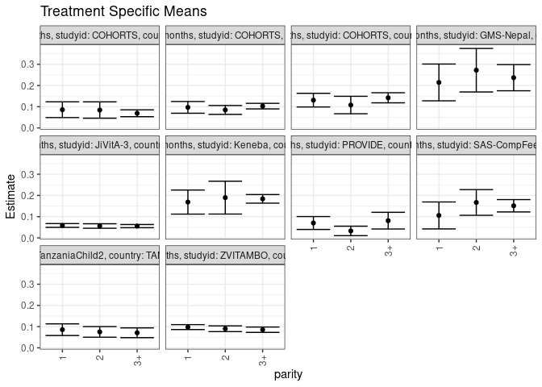

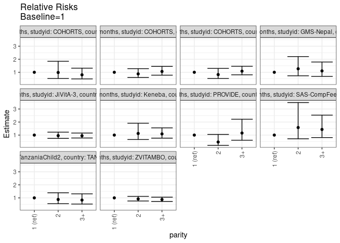

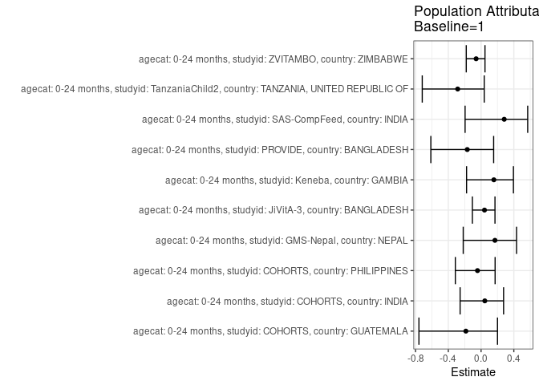

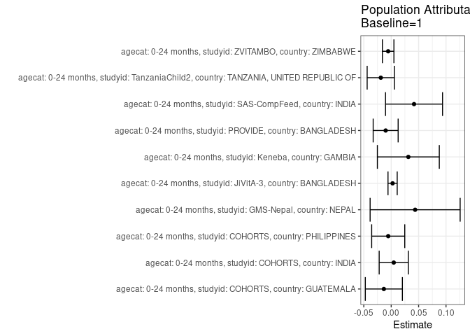

## Results Table

### Parameter: TSM

| agecat | studyid | country | intervention_level | baseline_level | estimate | ci_lower | ci_upper |
| --- | --- | --- | --- | --- | --- | --- | --- |
| 0-24 months | COHORTS | GUATEMALA | 1 | NA | 0.0857602 | 0.0486397 | 0.1228807 |
| 0-24 months | COHORTS | GUATEMALA | 2 | NA | 0.0842965 | 0.0457539 | 0.1228391 |
| 0-24 months | COHORTS | GUATEMALA | 3+ | NA | 0.0690078 | 0.0528760 | 0.0851397 |
| 0-24 months | COHORTS | INDIA | 1 | NA | 0.0967854 | 0.0690815 | 0.1244894 |
| 0-24 months | COHORTS | INDIA | 2 | NA | 0.0847173 | 0.0637347 | 0.1057000 |
| 0-24 months | COHORTS | INDIA | 3+ | NA | 0.1027552 | 0.0896553 | 0.1158551 |
| 0-24 months | COHORTS | PHILIPPINES | 1 | NA | 0.1309071 | 0.0986976 | 0.1631167 |
| 0-24 months | COHORTS | PHILIPPINES | 2 | NA | 0.1078297 | 0.0666338 | 0.1490255 |
| 0-24 months | COHORTS | PHILIPPINES | 3+ | NA | 0.1420013 | 0.1182374 | 0.1657651 |
| 0-24 months | GMS-Nepal | NEPAL | 1 | NA | 0.2143610 | 0.1277314 | 0.3009906 |
| 0-24 months | GMS-Nepal | NEPAL | 2 | NA | 0.2720065 | 0.1694273 | 0.3745858 |
| 0-24 months | GMS-Nepal | NEPAL | 3+ | NA | 0.2368613 | 0.1751682 | 0.2985544 |
| 0-24 months | JiVitA-3 | BANGLADESH | 1 | NA | 0.0584720 | 0.0495389 | 0.0674051 |
| 0-24 months | JiVitA-3 | BANGLADESH | 2 | NA | 0.0559243 | 0.0452999 | 0.0665488 |
| 0-24 months | JiVitA-3 | BANGLADESH | 3+ | NA | 0.0554220 | 0.0478937 | 0.0629503 |
| 0-24 months | Keneba | GAMBIA | 1 | NA | 0.1687511 | 0.1119275 | 0.2255747 |
| 0-24 months | Keneba | GAMBIA | 2 | NA | 0.1896740 | 0.1121674 | 0.2671806 |
| 0-24 months | Keneba | GAMBIA | 3+ | NA | 0.1839008 | 0.1636085 | 0.2041931 |
| 0-24 months | PROVIDE | BANGLADESH | 1 | NA | 0.0701107 | 0.0396891 | 0.1005323 |
| 0-24 months | PROVIDE | BANGLADESH | 2 | NA | 0.0327869 | 0.0104267 | 0.0551470 |
| 0-24 months | PROVIDE | BANGLADESH | 3+ | NA | 0.0810811 | 0.0417196 | 0.1204425 |
| 0-24 months | SAS-CompFeed | INDIA | 1 | NA | 0.1057364 | 0.0422013 | 0.1692715 |
| 0-24 months | SAS-CompFeed | INDIA | 2 | NA | 0.1669454 | 0.1063431 | 0.2275478 |
| 0-24 months | SAS-CompFeed | INDIA | 3+ | NA | 0.1513335 | 0.1222711 | 0.1803958 |
| 0-24 months | TanzaniaChild2 | TANZANIA, UNITED REPUBLIC OF | 1 | NA | 0.0856119 | 0.0581318 | 0.1130921 |
| 0-24 months | TanzaniaChild2 | TANZANIA, UNITED REPUBLIC OF | 2 | NA | 0.0750973 | 0.0501109 | 0.1000837 |
| 0-24 months | TanzaniaChild2 | TANZANIA, UNITED REPUBLIC OF | 3+ | NA | 0.0710256 | 0.0479373 | 0.0941140 |
| 0-24 months | ZVITAMBO | ZIMBABWE | 1 | NA | 0.0977823 | 0.0862109 | 0.1093537 |
| 0-24 months | ZVITAMBO | ZIMBABWE | 2 | NA | 0.0899941 | 0.0764295 | 0.1035587 |
| 0-24 months | ZVITAMBO | ZIMBABWE | 3+ | NA | 0.0853507 | 0.0727457 | 0.0979558 |

### Parameter: E(Y)

| agecat | studyid | country | intervention_level | baseline_level | estimate | ci_lower | ci_upper |
| --- | --- | --- | --- | --- | --- | --- | --- |
| 0-24 months | COHORTS | GUATEMALA | NA | NA | 0.0723341 | 0.0584645 | 0.0862036 |
| 0-24 months | COHORTS | INDIA | NA | NA | 0.1014273 | 0.0927249 | 0.1101298 |
| 0-24 months | COHORTS | PHILIPPINES | NA | NA | 0.1254516 | 0.1136848 | 0.1372183 |
| 0-24 months | GMS-Nepal | NEPAL | NA | NA | 0.2580175 | 0.2252514 | 0.2907836 |
| 0-24 months | JiVitA-3 | BANGLADESH | NA | NA | 0.0610254 | 0.0575469 | 0.0645038 |
| 0-24 months | Keneba | GAMBIA | NA | NA | 0.2000000 | 0.1824211 | 0.2175789 |
| 0-24 months | PROVIDE | BANGLADESH | NA | NA | 0.0600000 | 0.0423945 | 0.0776055 |
| 0-24 months | SAS-CompFeed | INDIA | NA | NA | 0.1473893 | 0.1184132 | 0.1763654 |
| 0-24 months | TanzaniaChild2 | TANZANIA, UNITED REPUBLIC OF | NA | NA | 0.0666101 | 0.0565417 | 0.0766785 |
| 0-24 months | ZVITAMBO | ZIMBABWE | NA | NA | 0.0922194 | 0.0874171 | 0.0970218 |

### Parameter: RR

| agecat | studyid | country | intervention_level | baseline_level | estimate | ci_lower | ci_upper |
| --- | --- | --- | --- | --- | --- | --- | --- |
| 0-24 months | COHORTS | GUATEMALA | 1 | 1 | 1.0000000 | 1.0000000 | 1.000000 |
| 0-24 months | COHORTS | GUATEMALA | 2 | 1 | 0.9829324 | 0.5236052 | 1.845200 |
| 0-24 months | COHORTS | GUATEMALA | 3+ | 1 | 0.8046606 | 0.4919216 | 1.316223 |
| 0-24 months | COHORTS | INDIA | 1 | 1 | 1.0000000 | 1.0000000 | 1.000000 |
| 0-24 months | COHORTS | INDIA | 2 | 1 | 0.8753108 | 0.5995433 | 1.277921 |
| 0-24 months | COHORTS | INDIA | 3+ | 1 | 1.0616806 | 0.7762663 | 1.452035 |
| 0-24 months | COHORTS | PHILIPPINES | 1 | 1 | 1.0000000 | 1.0000000 | 1.000000 |
| 0-24 months | COHORTS | PHILIPPINES | 2 | 1 | 0.8237111 | 0.5229414 | 1.297468 |
| 0-24 months | COHORTS | PHILIPPINES | 3+ | 1 | 1.0847482 | 0.8056063 | 1.460613 |
| 0-24 months | GMS-Nepal | NEPAL | 1 | 1 | 1.0000000 | 1.0000000 | 1.000000 |
| 0-24 months | GMS-Nepal | NEPAL | 2 | 1 | 1.2689178 | 0.7301366 | 2.205275 |
| 0-24 months | GMS-Nepal | NEPAL | 3+ | 1 | 1.1049644 | 0.6830341 | 1.787534 |
| 0-24 months | JiVitA-3 | BANGLADESH | 1 | 1 | 1.0000000 | 1.0000000 | 1.000000 |
| 0-24 months | JiVitA-3 | BANGLADESH | 2 | 1 | 0.9564295 | 0.7465297 | 1.225346 |
| 0-24 months | JiVitA-3 | BANGLADESH | 3+ | 1 | 0.9478381 | 0.7760756 | 1.157615 |
| 0-24 months | Keneba | GAMBIA | 1 | 1 | 1.0000000 | 1.0000000 | 1.000000 |
| 0-24 months | Keneba | GAMBIA | 2 | 1 | 1.1239868 | 0.6618489 | 1.908814 |
| 0-24 months | Keneba | GAMBIA | 3+ | 1 | 1.0897756 | 0.7646470 | 1.553149 |
| 0-24 months | PROVIDE | BANGLADESH | 1 | 1 | 1.0000000 | 1.0000000 | 1.000000 |
| 0-24 months | PROVIDE | BANGLADESH | 2 | 1 | 0.4676445 | 0.2083855 | 1.049456 |
| 0-24 months | PROVIDE | BANGLADESH | 3+ | 1 | 1.1564723 | 0.6030613 | 2.217732 |
| 0-24 months | SAS-CompFeed | INDIA | 1 | 1 | 1.0000000 | 1.0000000 | 1.000000 |
| 0-24 months | SAS-CompFeed | INDIA | 2 | 1 | 1.5788835 | 0.7131037 | 3.495807 |
| 0-24 months | SAS-CompFeed | INDIA | 3+ | 1 | 1.4312334 | 0.8095320 | 2.530387 |
| 0-24 months | TanzaniaChild2 | TANZANIA, UNITED REPUBLIC OF | 1 | 1 | 1.0000000 | 1.0000000 | 1.000000 |
| 0-24 months | TanzaniaChild2 | TANZANIA, UNITED REPUBLIC OF | 2 | 1 | 0.8771824 | 0.5530074 | 1.391390 |
| 0-24 months | TanzaniaChild2 | TANZANIA, UNITED REPUBLIC OF | 3+ | 1 | 0.8296232 | 0.5252619 | 1.310346 |
| 0-24 months | ZVITAMBO | ZIMBABWE | 1 | 1 | 1.0000000 | 1.0000000 | 1.000000 |
| 0-24 months | ZVITAMBO | ZIMBABWE | 2 | 1 | 0.9203514 | 0.7598617 | 1.114738 |
| 0-24 months | ZVITAMBO | ZIMBABWE | 3+ | 1 | 0.8728649 | 0.7223768 | 1.054703 |

### Parameter: PAR

| agecat | studyid | country | intervention_level | baseline_level | estimate | ci_lower | ci_upper |
| --- | --- | --- | --- | --- | --- | --- | --- |
| 0-24 months | COHORTS | GUATEMALA | 1 | NA | -0.0134261 | -0.0472487 | 0.0203965 |
| 0-24 months | COHORTS | INDIA | 1 | NA | 0.0046419 | -0.0219461 | 0.0312299 |
| 0-24 months | COHORTS | PHILIPPINES | 1 | NA | -0.0054556 | -0.0356291 | 0.0247180 |
| 0-24 months | GMS-Nepal | NEPAL | 1 | NA | 0.0436565 | -0.0384653 | 0.1257782 |
| 0-24 months | JiVitA-3 | BANGLADESH | 1 | NA | 0.0025534 | -0.0058419 | 0.0109486 |
| 0-24 months | Keneba | GAMBIA | 1 | NA | 0.0312489 | -0.0252403 | 0.0877381 |
| 0-24 months | PROVIDE | BANGLADESH | 1 | NA | -0.0101107 | -0.0328889 | 0.0126675 |
| 0-24 months | SAS-CompFeed | INDIA | 1 | NA | 0.0416529 | -0.0103557 | 0.0936615 |
| 0-24 months | TanzaniaChild2 | TANZANIA, UNITED REPUBLIC OF | 1 | NA | -0.0190018 | -0.0438878 | 0.0058841 |
| 0-24 months | ZVITAMBO | ZIMBABWE | 1 | NA | -0.0055629 | -0.0160843 | 0.0049586 |

### Parameter: PAF

| agecat | studyid | country | intervention_level | baseline_level | estimate | ci_lower | ci_upper |
| --- | --- | --- | --- | --- | --- | --- | --- |
| 0-24 months | COHORTS | GUATEMALA | 1 | NA | -0.1856126 | -0.7584928 | 0.2006353 |
| 0-24 months | COHORTS | INDIA | 1 | NA | 0.0457658 | -0.2557843 | 0.2749050 |
| 0-24 months | COHORTS | PHILIPPINES | 1 | NA | -0.0434875 | -0.3141113 | 0.1714049 |
| 0-24 months | GMS-Nepal | NEPAL | 1 | NA | 0.1691996 | -0.2178696 | 0.4332486 |
| 0-24 months | JiVitA-3 | BANGLADESH | 1 | NA | 0.0418411 | -0.1059873 | 0.1699105 |
| 0-24 months | Keneba | GAMBIA | 1 | NA | 0.1562446 | -0.1770657 | 0.3951713 |
| 0-24 months | PROVIDE | BANGLADESH | 1 | NA | -0.1685117 | -0.6132761 | 0.1536356 |
| 0-24 months | SAS-CompFeed | INDIA | 1 | NA | 0.2826047 | -0.1949953 | 0.5693238 |
| 0-24 months | TanzaniaChild2 | TANZANIA, UNITED REPUBLIC OF | 1 | NA | -0.2852696 | -0.7182033 | 0.0385783 |
| 0-24 months | ZVITAMBO | ZIMBABWE | 1 | NA | -0.0603220 | -0.1808216 | 0.0478809 |